# Big-LD

Sunah Kim (sunny03@snu.ac.kr)

# Big-LD

Big-LD is a block partition method based on interval graph modeling of LD bins which are clusters of strong pairwise LD SNPs, not necessarily physically consecutive. The detailed information about the Big-LD can be found in our paper published in [bioinformatics](https://academic.oup.com/bioinformatics/article/doi/10.1093/bioinformatics/btx609/4282661/A-new-haplotype-block-detection-method-for-dense).

## Installation

```r
library("devtools")
devtools::install_github("sunnyeesl/BigLD")
```

```r
library(BigLD)
```

## Data

You need an additive genotype data (each SNP genotype is coded in terms of the number of minor alleles) and a SNP information data. The package include sample genotype data and SNPinfo data.

Load the sample data (if you installed the BigLD packages).

```r
data(geno)
data(SNPinfo)
```

Or simply you can download the sample data from `/inst/extdata` The sample data include 1000SNPs and 286 individuals.

```r
geno[1:10, 1:7]
```

```
##    rs174309 rs174310 rs5747216 rs174312 rs174313 rs5747217 rs174314
## 1         0        0         0        0        0         0        0
## 2         1        1         0        0        1         1        1
## 3         0        0         0        0        0         0        0
## 4         1        1         0        0        1         1        1
## 5         1        1         0        0        1         1        1
## 6         2        2         0        0        2         2        2
## 7         2        2         0        1        2         1        2
## 8         0        0         1        0        0         0        0
## 9         0        0         0        0        0         0        0
## 10        1        1         1        0        1         1        1
```

```r
head(SNPinfo)
```

```
##        rsID       bp
## 1  rs174309 18000090
## 2  rs174310 18000280
## 3 rs5747216 18000829
## 4  rs174312 18001109
## 5  rs174313 18001375
## 6 rs5747217 18001894
```

## CLQD

`CLQD` partitioning the SNPs into subgroups such that each subgroup contains highly correlated SNPs. There are two CLQ methods, original CLQ(`ClQmode = 'Maximal'`) and CLQD (`ClQmode = 'Density'`).

```r
CLQres = CLQD(geno, SNPinfo, CLQmode = 'Density')
```

```
## [1] "end pre-steps"
```

```r
head(CLQres, n = 20)
```

```
##  [1]  25  25 106  57  25  81  25  25  57  57  15  15  15  81  57  26  26
## [18]  26  81  57
```

## Big_LD

’Big_LD` returns the estimation of LD block regions of given data.

```r
BigLDres = Big_LD(geno, SNPinfo)
```

```
## [1] "split whole sequence into subsegments"
## [1] "cutting sequence, done"
## [1] "there is only one sub-region!"
## [1] "end pre-steps"
## [1] "CLQ done!"
## [1] 1 1
## [1] "2017-10-19 17:00:34 KST"
```

```r
BigLDres
```

```
##    start  end  start.rsID    end.rsID start.bp   end.bp
## 1      1    2    rs174309    rs174310 18000090 18000280
## 2      3   54   rs5747216   rs2268780 18000829 18031530
## 3     58   69    rs174346    rs174358 18036253 18043090
## 4     70   77    rs174360    rs174365 18044257 18045084
## 5     78  101    rs174366    rs423158 18046680 18053496
## 6    102  113   rs1296810 rs148048073 18054369 18057141
## 7    114  116  rs75599514  rs77113684 18057200 18057362
## 8    119  120  rs60773453  rs74276474 18057926 18057936
## 9    121  123  rs74196725  rs12484668 18059204 18060356
## 10   124  132 rs185617591   rs4819604 18060385 18060457
## 11   136  161   rs2074343   rs5992751 18065981 18080154
## 12   162  302  rs73391480   rs5747302 18080431 18118204
## 13   303  512   rs9604777   rs1296687 18118636 18231046
## 14   513  538   rs2895951    rs181413 18232368 18239312
```

[output cut: 22 more lines]

If you want to apply heuristic procedure, add option `checkLargest = TRUE`.

```r
Big_LD(geno, SNPinfo, MAFcut = 0.05, checkLargest = TRUE, appendrare = TRUE)
```

## LDblockHeatmap

`LDblockHeatmap` visualize the LDblock boundaries detected by Big_LD.

You can input the results obtained using Big-LD (`LDblockResult= BigLDres`). If you do not input a Big-LD results, the `LDblockHeatmap` function first excute `Big_LD` function to obtain an LD block estimation result.

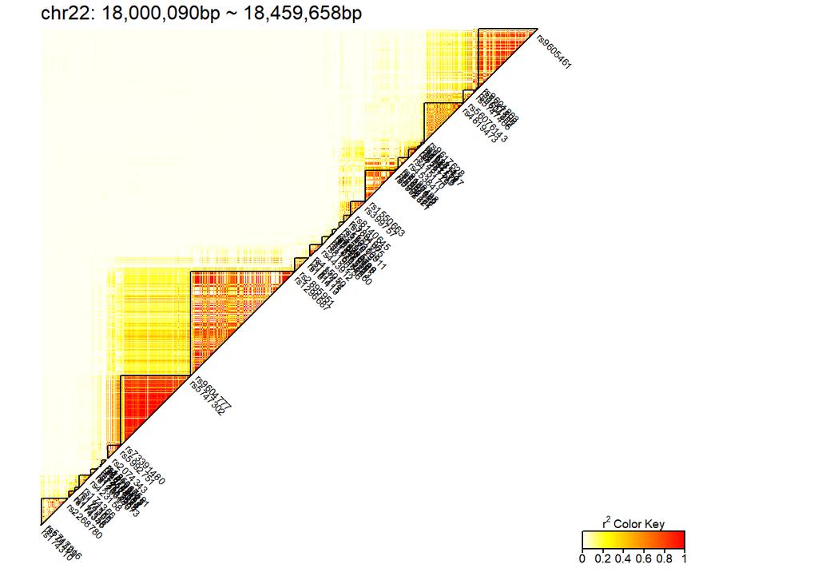

```r
LDblockHeatmap(geno, SNPinfo, 22, LDblockResult= BigLDres)
```

You can show the location of the specific SNPs (`showSNPs = SNPinfo[c(100, 200), ]` shows the 100th and 200th SNPs), or give the threshold for LD block sizes to show SNP information (`showLDsize = 50`). If you want to save the LD heatmap results as tif file, add options such as `savefile = TRUE, filename = "LDheatmap2.tif"`.

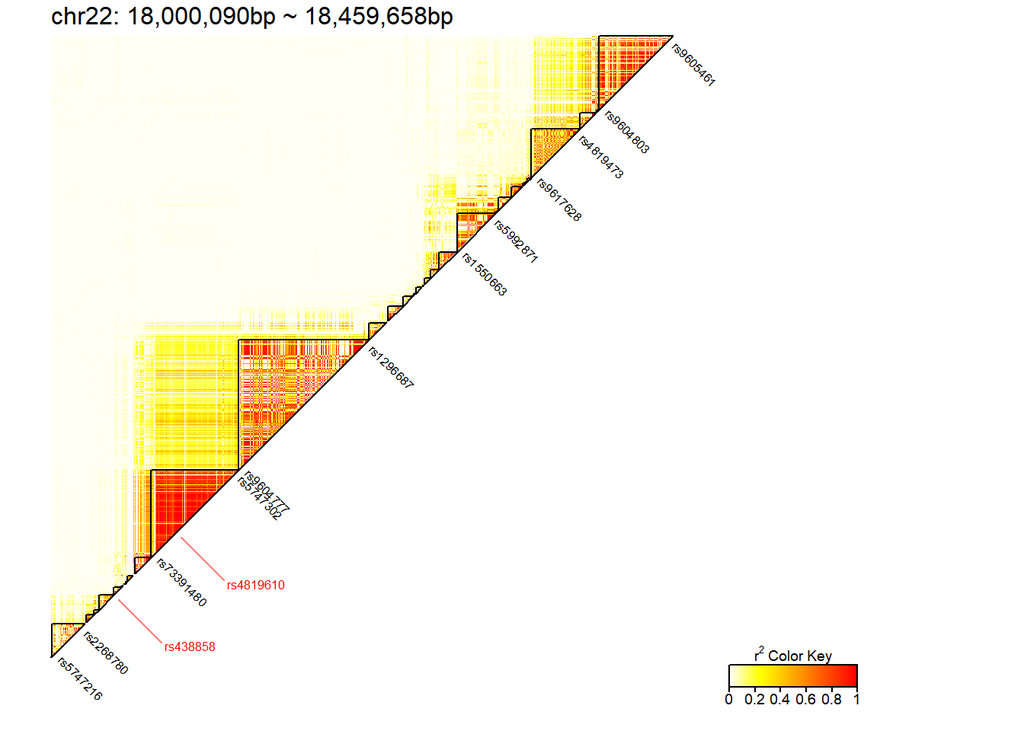

```r
LDblockHeatmap(geno, SNPinfo, 22, showSNPs = SNPinfo[c(100, 200), ], showLDsize = 50, savefile = TRUE, filename = "LDheatmap2.tif")
```